# Analysis & Trends of Twitch Games

Alex Van, Rana Odeh, Garret Shen

# Introduction:

We know and understand games to be a focal point of the entertainment industry. Whether you enjoy playing video games, or watching others play video games, games are a great way to relax and have fun with friends or family. Twitch is one of the growing platforms that allows users to watch other people live play games/chat (more discussion presented later). While not as relevant to certain individuals, we believe that analyzing trends in Twitch as well as popular games can gain a better understanding of the growing game industry as a whole. Specifically, we are studying the increase in average viewer count for popular games. This study allows us to understand what the gaming community comes to love and enjoy watching.

This tutorial/study guides us through 5 steps of data science analysis:  
1) Data Collection  
2) Data Processing  
3) Exploratory Analysis & Data Visualization 4) Model: Analysis, Hypothesis testing, and ML 5) Interpretation: Insight & Policy Decision

### What Is Twitch?

Released in 2011, [Twitch](https://www.twitch.tv/p/en/about/) is a streaming platform for all users to watch or hold live content for viewers to watch. In terms of what content is hosted on Twitch, lots of users mainly stream and watch video games (conventional or Esports related). However, there can be other categories such as podcasts or hangouts where streamers can collaborate and hangout with their viewers.

### Purpose

We understand that not everyone's interest is towards games and watching games. However, we wanted to pick a topic that motivated us and interested us to the best of our abilities. We also wanted to make sure the study was simple and easy to understand.

# Data Collection:

The first stage of the data science cycle is data collection. The data in which we collected can be found on kaggle, which is helpful for finding any databases in general. We decided to obviously choose a twitch data set: this set contains two data frames. The first dataframe is one that describes the most popular games on twitch from the years 2016-2023. The second data frame contains statistics for the overall views and information of Twitch from 2016-2023. The second data set is a generic gaming dataset. This dataset contains one dataframe that tells us popular games as a whole from 1980-2023.

Using python imports as well as [Pandas](https://pandas.pydata.org/docs/user_guide/index.html) read_csv method, we are able to read in multiple csv files. The sources to the csv files are linked below.

## Sources:

Twitch Dataset: [Evolution of Top Games on Twitch](https://www.kaggle.com/datasets/rankirsh/evolution-of-top-games-on-twitch/data)  
Game Dataset: [Popular Video Games 1980 - 2023](https://www.kaggle.com/datasets/arnabchaki/popular-video-games-1980-2023/data)

```python
# Imports:

import pandas as pd
import numpy as np
import matplotlib.pyplot as plt
import datetime as dt
import seaborn as sns
from sklearn.linear_model import SGDRegressor
import sklearn.model_selection as ms
from sklearn.metrics import mean_squared_error, r2_score
import warnings

warnings.filterwarnings('ignore')
```

```python
# We want to collect data from three csv files, each in their respective files/path.

df_twitch_games = pd.read_csv('TwitchData/Twitch_game_data.csv', encoding='latin1')
df_twitch_global = pd.read_csv('TwitchData/Twitch_global_data.csv', encoding='latin1')
df_games = pd.read_csv('GamesData/games.csv', encoding='latin1')
```

```python
df_twitch_games.head(10)
```

|  | Rank | Game | Month | Year | Hours_watched | Hours_streamed | Peak_viewers | Peak_channels | Streamers | Avg_viewers | Avg_channels | Avg_viewer_ratio |
| --- | --- | --- | --- | --- | --- | --- | --- | --- | --- | --- | --- | --- |
| 0 | 1 | League of Legends | 1 | 2016 | 94377226 | 1362044 | 530270 | 2903 | 129172 | 127021 | 1833 | 69.29 |
| 1 | 2 | Counter-Strike: Global Offensive | 1 | 2016 | 47832863 | 830105 | 372654 | 2197 | 120849 | 64378 | 1117 | 57.62 |
| 2 | 3 | Dota 2 | 1 | 2016 | 45185893 | 433397 | 315083 | 1100 | 44074 | 60815 | 583 | 104.26 |
| 3 | 4 | Hearthstone | 1 | 2016 | 39936159 | 235903 | 131357 | 517 | 36170 | 53749 | 317 | 169.29 |
| 4 | 5 | Call of Duty: Black Ops III | 1 | 2016 | 16153057 | 1151578 | 71639 | 3620 | 214054 | 21740 | 1549 | 14.03 |
| 5 | 6 | Minecraft | 1 | 2016 | 10231056 | 490002 | 64432 | 1538 | 88820 | 13769 | 659 | 20.88 |
| 6 | 7 | World of Warcraft | 1 | 2016 | 8771452 | 342978 | 46130 | 1180 | 33375 | 11805 | 461 | 25.57 |
| 7 | 8 | Z1: Battle Royale | 1 | 2016 | 7894571 | 205569 | 41588 | 460 | 21396 | 10625 | 276 | 38.40 |
| 8 | 9 | Talk Shows & Podcasts | 1 | 2016 | 7688369 | 53235 | 84051 | 148 | 10779 | 10347 | 71 | 144.42 |
| 9 | 10 | FIFA 16 | 1 | 2016 | 6988475 | 203646 | 145728 | 756 | 46462 | 9405 | 274 | 34.32 |

As described in the introduction, note how we have collected data of popular video games streamed on twitch over the time period of 2016-2023.

```python
df_twitch_global
```

|  | year | Month | Hours_watched | Avg_viewers | Peak_viewers | Streams | Avg_channels | Games_streamed | Viewer_ratio |
| --- | --- | --- | --- | --- | --- | --- | --- | --- | --- |
| 0 | 2016 | 1 | 480241904 | 646355 | 1275257 | 7701675 | 20076 | 12149 | 29.08 |
| 1 | 2016 | 2 | 441859897 | 635769 | 1308032 | 7038520 | 20427 | 12134 | 28.98 |
| 2 | 2016 | 3 | 490669308 | 660389 | 1591551 | 7390957 | 20271 | 12234 | 28.92 |
| 3 | 2016 | 4 | 377975447 | 525696 | 1775120 | 6869719 | 16791 | 12282 | 28.80 |
| 4 | 2016 | 5 | 449836631 | 605432 | 1438962 | 7535519 | 19394 | 12424 | 28.85 |
| ... | ... | ... | ... | ... | ... | ... | ... | ... | ... |
| 88 | 2023 | 5 | 1812569062 | 2439527 | 4354877 | 22173068 | 90764 | 43553 | 27.09 |
| 89 | 2023 | 6 | 1755716157 | 2441886 | 4633797 | 22164665 | 92217 | 43104 | 26.75 |
| 90 | 2023 | 7 | 1826259969 | 2457954 | 6242790 | 23559408 | 93179 | 44571 | 26.57 |
| 91 | 2023 | 8 | 1787298991 | 2405516 | 4106733 | 23615116 | 94839 | 44060 | 25.46 |
| 92 | 2023 | 9 | 1690480123 | 2351154 | 4593138 | 23098283 | 96346 | 42640 | 24.63 |

93 rows × 9 columns

Although not all data is present, we have all the data we need from 2016-2023 of hours watched, average viewers, peak viewers, streams (probably the number of streams hosted), average channels (number of channels), games streamed, and viewer ratio.

```python
df_games.head(10)
```

|  | Unnamed: 0 | Title | Release Date | Team | Rating | Times Listed | Number of Reviews | Genres | Summary | Reviews | Plays | Playing | Backlogs | Wishlist |
| --- | --- | --- | --- | --- | --- | --- | --- | --- | --- | --- | --- | --- | --- | --- |
| 0 | 0 | Elden Ring | Feb 25, 2022 | ['Bandai Namco Entertainment', 'FromSoftware'] | 4.5 | 3.9K | 3.9K | ['Adventure', 'RPG'] | Elden Ring is a fantasy, action and open world... | ["The first playthrough of elden ring is one o... | 17K | 3.8K | 4.6K | 4.8K |
| 1 | 1 | Hades | Dec 10, 2019 | ['Supergiant Games'] | 4.3 | 2.9K | 2.9K | ['Adventure', 'Brawler', 'Indie', 'RPG'] | A rogue-lite hack and slash dungeon crawler in... | ['convinced this is a roguelike for people who... | 21K | 3.2K | 6.3K | 3.6K |
| 2 | 2 | The Legend of Zelda: Breath of the Wild | Mar 03, 2017 | ['Nintendo', 'Nintendo EPD Production Group No... | 4.4 | 4.3K | 4.3K | ['Adventure', 'RPG'] | The Legend of Zelda: Breath of the Wild is the... | ['This game is the game (that is not CS:GO) th... | 30K | 2.5K | 5K | 2.6K |
| 3 | 3 | Undertale | Sep 15, 2015 | ['tobyfox', '8-4'] | 4.2 | 3.5K | 3.5K | ['Adventure', 'Indie', 'RPG', 'Turn Based Stra... | A small child falls into the Underground, wher... | ['soundtrack is tied for #1 with nier automata... | 28K | 679 | 4.9K | 1.8K |
| 4 | 4 | Hollow Knight | Feb 24, 2017 | ['Team Cherry'] | 4.4 | 3K | 3K | ['Adventure', 'Indie', 'Platform'] | A 2D metroidvania with an emphasis on close co... | ["this games worldbuilding is incredible, with... | 21K | 2.4K | 8.3K | 2.3K |
| 5 | 5 | Minecraft | Nov 18, 2011 | ['Mojang Studios'] | 4.3 | 2.3K | 2.3K | ['Adventure', 'Simulator'] | Minecraft focuses on allowing the player to ex... | ['Minecraft is what you make of it. Unfortunat... | 33K | 1.8K | 1.1K | 230 |
| 6 | 6 | Omori | Dec 25, 2020 | ['OMOCAT', 'PLAYISM'] | 4.2 | 1.6K | 1.6K | ['Adventure', 'Indie', 'RPG', 'Turn Based Stra... | A turn-based surreal horror RPG in which a chi... | ["The best game I've played in my life", "omor... | 7.2K | 1.1K | 4.5K | 3.8K |
| 7 | 7 | Metroid Dread | Oct 07, 2021 | ['Nintendo', 'MercurySteam'] | 4.3 | 2.1K | 2.1K | ['Adventure', 'Platform'] | Join intergalactic bounty hunter Samus Aran in... | ['Have only been a Metroid fan for couple of y... | 9.2K | 759 | 3.4K | 3.3K |
| 8 | 8 | Among Us | Jun 15, 2018 | ['InnerSloth'] | 3.0 | 867 | 867 | ['Indie', 'Strategy'] | Join your crew-mates in a multiplayer game of ... | ["it's a solid party game. i'm bad at lying th... | 25K | 470 | 776 | 126 |
| 9 | 9 | NieR: Automata | Feb 23, 2017 | ['PlatinumGames', 'Square Enix'] | 4.3 | 2.9K | 2.9K | ['Brawler', 'RPG'] | NieR: Automata tells the story of androids 2B,... | ['Holy shit', 'im carrying the weight of the w... | 18K | 1.1K | 6.2K | 3.6K |

Lastly, we have popular game titles and their release dates. As well, we have their genres, company, rating, genre, reviews, etc. Although not for this project, we could perform sentimental analysis on this dataset based off of reviews, as it is a topic in machine learning and data science.

# Data Processing:

The next stage in the data science process and of this study is data processing. Now that we have the data, we need to process and clean this data so it can be useable for future uses of our study and visualization. What we consider as clean data is to remove any unnecessary information (this can be columns, or missing/Nan values). In addition, we can use certain libraries we have imported to our advantage of cleaning and processing this data. Libraries such as [Pandas](https://pandas.pydata.org/docs/user_guide/index.html) and [NumPy](https://numpy.org/doc/stable/) are notable and helpful libraries. These libraries contain methods crucial for processing data.

Notably for this project, we want to clean data from our three dataframes that we have collected, for example, we can remove the reviews from our games dataframe, as we will not be needing that.

```python
df_twitch_games.dtypes
```

```
Rank                  int64
Game                 object
Month                 int64
Year                  int64
Hours_watched         int64
Hours_streamed        int64
Peak_viewers          int64
Peak_channels         int64
Streamers             int64
Avg_viewers           int64
Avg_channels          int64
Avg_viewer_ratio    float64
dtype: object
```

```python
df_twitch_global.dtypes
```

```
year                int64
Month               int64
Hours_watched       int64
Avg_viewers         int64
Peak_viewers        int64
Streams             int64
Avg_channels        int64
Games_streamed      int64
Viewer_ratio      float64
dtype: object
```

```python
df_games.dtypes
```

```
Unnamed: 0             int64
Title                 object
Release Date          object
Team                  object
Rating               float64
Times Listed          object
Number of Reviews     object
Genres                object
Summary               object
Reviews               object
Plays                 object
Playing               object
Backlogs              object
Wishlist              object
dtype: object
```

The first two dataframes have type columns that I want. Lets try to manipulate the third data frame's type. As well, we should probably combine and get rid of columns as necessary. First however, lets drop any missing columns

```python
df_twitch_games.isnull().sum()
```

```
Rank                0
Game                1
Month               0
Year                0
Hours_watched       0
Hours_streamed      0
Peak_viewers        0
Peak_channels       0
Streamers           0
Avg_viewers         0
Avg_channels        0
Avg_viewer_ratio    0
dtype: int64
```

```python
df_twitch_global.isnull().sum()
```

```
year              0
Month             0
Hours_watched     0
Avg_viewers       0
Peak_viewers      0
Streams           0
Avg_channels      0
Games_streamed    0
Viewer_ratio      0
dtype: int64
```

```python
df_games.isnull().sum()
```

```
Unnamed: 0            0
Title                 0
Release Date          0
Team                  1
Rating               13
Times Listed          0
Number of Reviews     0
Genres                0
Summary               1
Reviews               0
Plays                 0
Playing               0
Backlogs              0
Wishlist              0
dtype: int64
```

```python
df_games[df_games.isna().any(axis=1)]
```

|  | Unnamed: 0 | Title | Release Date | Team | Rating | Times Listed | Number of Reviews | Genres | Summary | Reviews | Plays | Playing | Backlogs | Wishlist |
| --- | --- | --- | --- | --- | --- | --- | --- | --- | --- | --- | --- | --- | --- | --- |
| 587 | 587 | Final Fantasy XVI | Jun 22, 2023 | ['Square Enix', 'Square Enix Creative Business... | NaN | 422 | 422 | ['RPG'] | Final Fantasy XVI is an upcoming action role-p... | [] | 37 | 10 | 732 | 2.4K |
| 649 | 649 | Death Stranding 2 | releases on TBD | ['Kojima Productions'] | NaN | 105 | 105 | ['Adventure', 'Shooter'] | NaN | [] | 3 | 0 | 209 | 644 |
| 713 | 713 | Final Fantasy VII Rebirth | Dec 31, 2023 | ['Square Enix'] | NaN | 192 | 192 | [] | This next standalone chapter in the FINAL FANT... | [] | 20 | 3 | 354 | 1.1K |
| 719 | 719 | Lies of P | Aug 01, 2023 | ['NEOWIZ', 'Round8 Studio'] | NaN | 175 | 175 | ['RPG'] | Inspired by the familiar story of Pinocchio, L... | [] | 5 | 0 | 260 | 939 |
| 726 | 726 | Judas | Mar 31, 2025 | ['Ghost Story Games'] | NaN | 90 | 90 | ['Adventure', 'Shooter'] | A disintegrating starship. A desperate escape ... | [] | 1 | 0 | 92 | 437 |
| 746 | 746 | Like a Dragon Gaiden: The Man Who Erased His Name | Dec 31, 2023 | ['RyÅ« Ga Gotoku Studios', 'Sega'] | NaN | 118 | 118 | ['Adventure', 'Brawler', 'RPG'] | This game covers Kiryu's story between Yakuza ... | [] | 2 | 1 | 145 | 588 |
| 972 | 972 | The Legend of Zelda: Tears of the Kingdom | May 12, 2023 | ['Nintendo', 'Nintendo EPD Production Group No... | NaN | 581 | 581 | ['Adventure', 'RPG'] | The Legend of Zelda: Tears of the Kingdom is t... | [] | 72 | 6 | 1.6K | 5.4K |
| 1130 | 1130 | Star Wars Jedi: Survivor | Apr 28, 2023 | ['Respawn Entertainment', 'Electronic Arts'] | NaN | 250 | 250 | ['Adventure'] | The story of Cal Kestis continues in Star Wars... | [] | 13 | 2 | 367 | 1.4K |
| 1160 | 1160 | We Love Katamari Reroll + Royal Reverie | Jun 02, 2023 | ['Bandai Namco Entertainment', 'MONKEYCRAFT Co... | NaN | 51 | 51 | ['Adventure', 'Puzzle'] | We Love Katamari Reroll + Royal Reverie is a r... | [] | 3 | 0 | 74 | 291 |
| 1202 | 1202 | Earthblade | Dec 31, 2024 | ['Extremely OK Games'] | NaN | 83 | 83 | ['Adventure', 'Indie', 'RPG'] | You are Névoa, an enigmatic child of Fate ret... | [] | 0 | 1 | 103 | 529 |
| 1245 | 1245 | NEET Girl Date Night | Oct 21, 2022 | NaN | 2.7 | 21 | 21 | ['Visual Novel'] | Your friend sets you up on a date with his NEE... | ['this sucked. "Omg she is literally me" is no... | 106 | 1 | 44 | 42 |
| 1305 | 1305 | Diablo IV | Jun 06, 2023 | ['Blizzard Entertainment'] | NaN | 148 | 148 | ['Brawler', 'RPG'] | Endless demons to slaughter. Deep customizatio... | [] | 19 | 10 | 179 | 677 |
| 1341 | 1341 | Pac-Man in a Tin | Mar 22, 2023 | ['Fizz Creations'] | NaN | 0 | 0 | ['Arcade'] | Pac-Man in a Tin is a pocket-sized tin contain... | [] | 1 | 0 | 1 | 2 |
| 1349 | 1349 | Pokémon Añil | Mar 23, 2023 | ['Eric Lost'] | NaN | 2 | 2 | ['RPG'] | Pokémon Añil is the fourth video game create... | ['pokemon HWHAT', 'Finally, after all these ye... | 1 | 0 | 1 | 7 |

It seems that All seem to be missing a rating except NEET Girl Date Night. However, NEET Girl Date Night does not have a company, and that is data we do not want to include in the original data set. We can simply remove any nan or missing values.

First lets drop the missing values. After, lets create methods to modify the columns and tidy up the data for each dataframe.

```python
# This is a method to modify the column of the twitch_games dataframe.
def modify_twitch_game_col(df):

    # I want to rewrite the date column for clarity
    df['Date'] = df.apply(lambda row: pd.Period(year=row['Year'], month=row['Month'], freq='M'), axis=1)

    # Delete the month and year columns
    del df['Month']
    del df['Year']

    # Reorder the columns
    reorder = ["Rank", "Date", "Game", "Hours_watched", "Hours_streamed", "Peak_viewers", "Peak_channels", "Streamers", "Avg_viewers", "Avg_channels", "Avg_viewer_ratio"]
    df = df.reindex(columns = reorder)

    # Rename the columns
    rename = {"Hours_watched": "Hours Watched", "Hours_streamed": "Hours Streamed", "Peak_viewers": "Maximum Viewers", "Peak_channels": "Maximum Channels", "Streamers": "Number of Streamers",
              "Avg_viewers": "Average Viewer Count", "Avg_channels": "Average Channel Count", "Avg_viewer_ratio": "Average Viewer Ratio"}
    df = df.rename(columns = rename)

    return df
```

```python
def modify_twitch_global_col(df):

    # Rewrite the date column
    df['Date'] = df.apply(lambda row: pd.Period(year=row['year'], month=row['Month'], freq='M'), axis=1)

    # Reorder the columns
    reorder = ["Date", "Hours_watched", "Avg_viewers", "Peak_viewers", "Streams", "Avg_channels", "Games_streamed", "Viewer_ratio"]
    df = df.reindex(columns = reorder)

    # Rename the columns
    rename = {"Hours_watched": "Hours Watched", "Peak_viewers": "Maximum Viewers", "Streams": "Number of Streames",
              "Avg_viewers": "Average Viewer Count", "Avg_channels": "Average Channel Count", "Viewer_ratio": "Average Viewer Ratio",
             "Games_streamed": "Number of Games Streamed"}
    df = df.rename(columns = rename)

    return df
```

```python
months = {"Jan": 1, "Feb": 2, "Mar": 3, "Apr": 4, "May": 5, "Jun": 6, "Jul": 7, "Aug": 8, "Sep": 9, "Oct":10,
         "Nov": 11, "Dec": 12}

def modify_games_col(df):

    for index, row in df.iterrows():

        year_data = row['Release Date'][len(row['Release Date'])-5:]
        month_word = row['Release Date'][:3]

        # Check if the month is in the dictionary, As well we want data from 2016 and over.
        if month_word in months:
            # Convert the month to the corresponding numeric value
            month_num = months[month_word]

            # Convert the release date to pd.Period()
            df.at[index, 'Release Date'] = pd.Period(year=int(year_data), month=month_num, freq='M')
        else:
            df = df.drop(index)

    # Lets now remove the unecessary columns
    del df['Unnamed: 0']
    del df['Times Listed']
    del df['Summary']
    del df['Reviews']
    del df['Playing']
    del df['Backlogs']

    rename = {"Title": "Game"}
    df = df.rename(columns = rename)

    # Rearrange Columns
    reorder = ["Release Date", "Game", "Rating", "Number of Reviews", "Plays", "Wishlist", "Team", "Genres"]
    df = df.reindex(columns = reorder)

    return df
```

```python
df_twitch_games = modify_twitch_game_col(df_twitch_games)
df_twitch_global = modify_twitch_global_col(df_twitch_global)
df_games = modify_games_col(df_games)
```

We have now cleaned up the data. We have put it in a format that's readable as well as getting rid of any missing values as necessary as displayed below.

```python
df_twitch_games.head(10)
```

|  | Rank | Date | Game | Hours Watched | Hours Streamed | Maximum Viewers | Maximum Channels | Number of Streamers | Average Viewer Count | Average Channel Count | Average Viewer Ratio |
| --- | --- | --- | --- | --- | --- | --- | --- | --- | --- | --- | --- |
| 0 | 1 | 2016-01 | League of Legends | 94377226 | 1362044 | 530270 | 2903 | 129172 | 127021 | 1833 | 69.29 |
| 1 | 2 | 2016-01 | Counter-Strike: Global Offensive | 47832863 | 830105 | 372654 | 2197 | 120849 | 64378 | 1117 | 57.62 |
| 2 | 3 | 2016-01 | Dota 2 | 45185893 | 433397 | 315083 | 1100 | 44074 | 60815 | 583 | 104.26 |
| 3 | 4 | 2016-01 | Hearthstone | 39936159 | 235903 | 131357 | 517 | 36170 | 53749 | 317 | 169.29 |
| 4 | 5 | 2016-01 | Call of Duty: Black Ops III | 16153057 | 1151578 | 71639 | 3620 | 214054 | 21740 | 1549 | 14.03 |
| 5 | 6 | 2016-01 | Minecraft | 10231056 | 490002 | 64432 | 1538 | 88820 | 13769 | 659 | 20.88 |
| 6 | 7 | 2016-01 | World of Warcraft | 8771452 | 342978 | 46130 | 1180 | 33375 | 11805 | 461 | 25.57 |
| 7 | 8 | 2016-01 | Z1: Battle Royale | 7894571 | 205569 | 41588 | 460 | 21396 | 10625 | 276 | 38.40 |
| 8 | 9 | 2016-01 | Talk Shows & Podcasts | 7688369 | 53235 | 84051 | 148 | 10779 | 10347 | 71 | 144.42 |
| 9 | 10 | 2016-01 | FIFA 16 | 6988475 | 203646 | 145728 | 756 | 46462 | 9405 | 274 | 34.32 |

```python
df_twitch_global.head(10)
```

|  | Date | Hours Watched | Average Viewer Count | Maximum Viewers | Number of Streames | Average Channel Count | Number of Games Streamed | Average Viewer Ratio |
| --- | --- | --- | --- | --- | --- | --- | --- | --- |
| 0 | 2016-01 | 480241904 | 646355 | 1275257 | 7701675 | 20076 | 12149 | 29.08 |
| 1 | 2016-02 | 441859897 | 635769 | 1308032 | 7038520 | 20427 | 12134 | 28.98 |
| 2 | 2016-03 | 490669308 | 660389 | 1591551 | 7390957 | 20271 | 12234 | 28.92 |
| 3 | 2016-04 | 377975447 | 525696 | 1775120 | 6869719 | 16791 | 12282 | 28.80 |
| 4 | 2016-05 | 449836631 | 605432 | 1438962 | 7535519 | 19394 | 12424 | 28.85 |
| 5 | 2016-06 | 446429345 | 620903 | 1755888 | 6663363 | 18818 | 12374 | 28.76 |
| 6 | 2016-07 | 446331825 | 600715 | 1453743 | 7336215 | 18030 | 12961 | 28.62 |
| 7 | 2016-08 | 382117373 | 514289 | 1334490 | 6837386 | 16592 | 13693 | 28.47 |
| 8 | 2016-09 | 362833210 | 504635 | 1186009 | 6623528 | 16880 | 13484 | 28.39 |
| 9 | 2016-10 | 453035001 | 609737 | 1549150 | 6771852 | 19250 | 13973 | 28.33 |

```python
# Drop both duplicate and Nan values now
df_games.drop_duplicates(inplace=True)
df_games.dropna(inplace=True) # Drop NAN values

df_games.head(10)
```

|  | Release Date | Game | Rating | Number of Reviews | Plays | Wishlist | Team | Genres |
| --- | --- | --- | --- | --- | --- | --- | --- | --- |
| 0 | 2022-02 | Elden Ring | 4.5 | 3.9K | 17K | 4.8K | ['Bandai Namco Entertainment', 'FromSoftware'] | ['Adventure', 'RPG'] |
| 1 | 2019-12 | Hades | 4.3 | 2.9K | 21K | 3.6K | ['Supergiant Games'] | ['Adventure', 'Brawler', 'Indie', 'RPG'] |
| 2 | 2017-03 | The Legend of Zelda: Breath of the Wild | 4.4 | 4.3K | 30K | 2.6K | ['Nintendo', 'Nintendo EPD Production Group No... | ['Adventure', 'RPG'] |
| 3 | 2015-09 | Undertale | 4.2 | 3.5K | 28K | 1.8K | ['tobyfox', '8-4'] | ['Adventure', 'Indie', 'RPG', 'Turn Based Stra... |
| 4 | 2017-02 | Hollow Knight | 4.4 | 3K | 21K | 2.3K | ['Team Cherry'] | ['Adventure', 'Indie', 'Platform'] |
| 5 | 2011-11 | Minecraft | 4.3 | 2.3K | 33K | 230 | ['Mojang Studios'] | ['Adventure', 'Simulator'] |
| 6 | 2020-12 | Omori | 4.2 | 1.6K | 7.2K | 3.8K | ['OMOCAT', 'PLAYISM'] | ['Adventure', 'Indie', 'RPG', 'Turn Based Stra... |
| 7 | 2021-10 | Metroid Dread | 4.3 | 2.1K | 9.2K | 3.3K | ['Nintendo', 'MercurySteam'] | ['Adventure', 'Platform'] |
| 8 | 2018-06 | Among Us | 3.0 | 867 | 25K | 126 | ['InnerSloth'] | ['Indie', 'Strategy'] |
| 9 | 2017-02 | NieR: Automata | 4.3 | 2.9K | 18K | 3.6K | ['PlatinumGames', 'Square Enix'] | ['Brawler', 'RPG'] |

Now that we have all three dataframes, we can also create another data frame that merges the games that have been popular on twitch (df_twitch_games), and the global games dataframe (df_games). We can see the overlap between the two by setting its property to inner.

Inner means that when merging, we only show columns that intersect each other.  
Outer is the opposite, meaning when we merge, we show all values whether they intersect or do not intersect each other.

```python
twitch_total_df = pd.merge(df_twitch_games, df_games, on='Game', how='inner')
twitch_total_df.head(20)
```

|  | Rank | Date | Game | Hours Watched | Hours Streamed | Maximum Viewers | Maximum Channels | Number of Streamers | Average Viewer Count | Average Channel Count | Average Viewer Ratio | Release Date | Rating | Number of Reviews | Plays | Wishlist | Team | Genres |
| --- | --- | --- | --- | --- | --- | --- | --- | --- | --- | --- | --- | --- | --- | --- | --- | --- | --- | --- |
| 0 | 1 | 2016-01 | League of Legends | 94377226 | 1362044 | 530270 | 2903 | 129172 | 127021 | 1833 | 69.29 | 2009-10 | 2.1 | 484 | 13K | 52 | ['GOA Games Services Ltd.', 'Riot Games'] | ['MOBA', 'RPG', 'Strategy'] |
| 1 | 1 | 2016-02 | League of Legends | 93154772 | 1266715 | 475784 | 2712 | 117996 | 134035 | 1822 | 73.54 | 2009-10 | 2.1 | 484 | 13K | 52 | ['GOA Games Services Ltd.', 'Riot Games'] | ['MOBA', 'RPG', 'Strategy'] |
| 2 | 1 | 2016-03 | League of Legends | 94514511 | 1264029 | 599114 | 2585 | 117734 | 127206 | 1701 | 74.77 | 2009-10 | 2.1 | 484 | 13K | 52 | ['GOA Games Services Ltd.', 'Riot Games'] | ['MOBA', 'RPG', 'Strategy'] |
| 3 | 1 | 2016-04 | League of Legends | 88389049 | 1217250 | 553165 | 2945 | 113251 | 122933 | 1692 | 72.61 | 2009-10 | 2.1 | 484 | 13K | 52 | ['GOA Games Services Ltd.', 'Riot Games'] | ['MOBA', 'RPG', 'Strategy'] |
| 4 | 1 | 2016-05 | League of Legends | 80679320 | 1196096 | 433005 | 2635 | 118593 | 108585 | 1609 | 67.45 | 2009-10 | 2.1 | 484 | 13K | 52 | ['GOA Games Services Ltd.', 'Riot Games'] | ['MOBA', 'RPG', 'Strategy'] |
| 5 | 1 | 2016-06 | League of Legends | 81348505 | 1037242 | 346059 | 2131 | 102620 | 113141 | 1442 | 78.43 | 2009-10 | 2.1 | 484 | 13K | 52 | ['GOA Games Services Ltd.', 'Riot Games'] | ['MOBA', 'RPG', 'Strategy'] |
| 6 | 1 | 2016-07 | League of Legends | 77871713 | 1004238 | 296196 | 2089 | 105041 | 104807 | 1351 | 77.54 | 2009-10 | 2.1 | 484 | 13K | 52 | ['GOA Games Services Ltd.', 'Riot Games'] | ['MOBA', 'RPG', 'Strategy'] |
| 7 | 1 | 2016-08 | League of Legends | 81684707 | 1097258 | 502181 | 2177 | 105795 | 109939 | 1476 | 74.44 | 2009-10 | 2.1 | 484 | 13K | 52 | ['GOA Games Services Ltd.', 'Riot Games'] | ['MOBA', 'RPG', 'Strategy'] |
| 8 | 1 | 2016-09 | League of Legends | 81064642 | 1087244 | 711103 | 2493 | 110946 | 112746 | 1512 | 74.56 | 2009-10 | 2.1 | 484 | 13K | 52 | ['GOA Games Services Ltd.', 'Riot Games'] | ['MOBA', 'RPG', 'Strategy'] |
| 9 | 1 | 2016-10 | League of Legends | 104305242 | 1155966 | 952308 | 2591 | 111071 | 140383 | 1555 | 90.23 | 2009-10 | 2.1 | 484 | 13K | 52 | ['GOA Games Services Ltd.', 'Riot Games'] | ['MOBA', 'RPG', 'Strategy'] |
| 10 | 1 | 2016-11 | League of Legends | 76730765 | 1127714 | 263539 | 2903 | 103085 | 106718 | 1568 | 68.04 | 2009-10 | 2.1 | 484 | 13K | 52 | ['GOA Games Services Ltd.', 'Riot Games'] | ['MOBA', 'RPG', 'Strategy'] |
| 11 | 1 | 2016-12 | League of Legends | 81349398 | 1241696 | 323032 | 2562 | 36118 | 109487 | 1671 | 65.51 | 2009-10 | 2.1 | 484 | 13K | 52 | ['GOA Games Services Ltd.', 'Riot Games'] | ['MOBA', 'RPG', 'Strategy'] |
| 12 | 1 | 2017-01 | League of Legends | 99332369 | 1363324 | 379399 | 2868 | 129423 | 133690 | 1834 | 72.86 | 2009-10 | 2.1 | 484 | 13K | 52 | ['GOA Games Services Ltd.', 'Riot Games'] | ['MOBA', 'RPG', 'Strategy'] |
| 13 | 1 | 2017-02 | League of Legends | 99415477 | 1209135 | 386334 | 2770 | 114317 | 148160 | 1801 | 82.22 | 2009-10 | 2.1 | 484 | 13K | 52 | ['GOA Games Services Ltd.', 'Riot Games'] | ['MOBA', 'RPG', 'Strategy'] |
| 14 | 1 | 2017-03 | League of Legends | 90835130 | 1189566 | 325835 | 2465 | 96112 | 122254 | 1601 | 76.36 | 2009-10 | 2.1 | 484 | 13K | 52 | ['GOA Games Services Ltd.', 'Riot Games'] | ['MOBA', 'RPG', 'Strategy'] |
| 15 | 1 | 2017-04 | League of Legends | 82852693 | 1179314 | 489683 | 2540 | 97370 | 115233 | 1640 | 70.25 | 2009-10 | 2.1 | 484 | 13K | 52 | ['GOA Games Services Ltd.', 'Riot Games'] | ['MOBA', 'RPG', 'Strategy'] |
| 16 | 1 | 2017-05 | League of Legends | 87929525 | 1231374 | 647413 | 2498 | 121711 | 118343 | 1657 | 71.41 | 2009-10 | 2.1 | 484 | 13K | 52 | ['GOA Games Services Ltd.', 'Riot Games'] | ['MOBA', 'RPG', 'Strategy'] |
| 17 | 1 | 2017-06 | League of Legends | 84467396 | 1149523 | 280837 | 2330 | 116484 | 117478 | 1598 | 73.48 | 2009-10 | 2.1 | 484 | 13K | 52 | ['GOA Games Services Ltd.', 'Riot Games'] | ['MOBA', 'RPG', 'Strategy'] |
| 18 | 1 | 2017-07 | League of Legends | 84734733 | 1301262 | 326063 | 2481 | 125411 | 114044 | 1751 | 65.12 | 2009-10 | 2.1 | 484 | 13K | 52 | ['GOA Games Services Ltd.', 'Riot Games'] | ['MOBA', 'RPG', 'Strategy'] |
| 19 | 2 | 2017-08 | League of Legends | 72054710 | 1260651 | 343402 | 2668 | 121195 | 96978 | 1696 | 57.16 | 2009-10 | 2.1 | 484 | 13K | 52 | ['GOA Games Services Ltd.', 'Riot Games'] | ['MOBA', 'RPG', 'Strategy'] |

# Exploratory Analysis & Data Visualization:

The next step of the data science process and of this study is to visually analyze the data and dataframes we have merged/created. We can use the [Matlabplot library](https://matplotlib.org/stable/index.html), [seaborn](https://seaborn.pydata.org/tutorial.html), or other Python graphing libraries to achieve this. This part of the process allows us to use the information we have gotten to visualize and predict future outcomes.

Lets now use our second dataframe (not the merged one) to create a graph. Lets create a graph of the number of hours watched on Twitch over time using Matlabplot Library.

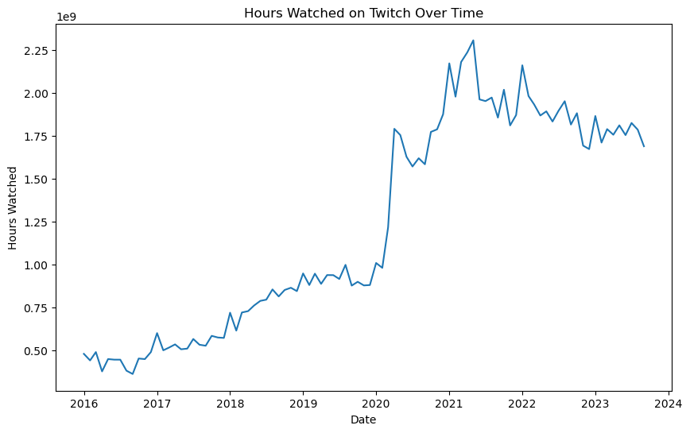

```python
# This converts the 'Date' column in our dataframe to a datetime format. This is done to make sure that we are able to plot
# The date (since they are in Y-M format) which would not work to plot.
df_twitch_global["Date"] = df_twitch_global["Date"].astype("datetime64")

plt.figure(figsize=(10, 6))
plt.plot(df_twitch_global['Date'], df_twitch_global['Hours Watched'])
plt.xlabel('Date')
plt.ylabel('Hours Watched')
plt.title('Hours Watched on Twitch Over Time')
plt.show()
```

Awesome! just by using the code presented above we are able to see the data come to life. From this plot we can tell so much about this data that we would not have been able to tell as quickly if we did not plot it. For example, based on this plot, we can see that throughout 2016-2023 there is a general increase in the total hours watched on Twitch. This indicates that there is a growing popularity of the platform over the years. In addition, another very important aspect that we can gather from this plot is that there is a sharp increase in hours watched around 2020. This was during the time of the global COVID-19 pandemic, which shows us that while people were under lockdown they used streaming platforms such as Twitch for entertainment.

Just from this one graph we were able to gather so much information! Now lets move on to graphing different parts of the data so we can get even more information (So much fun!).

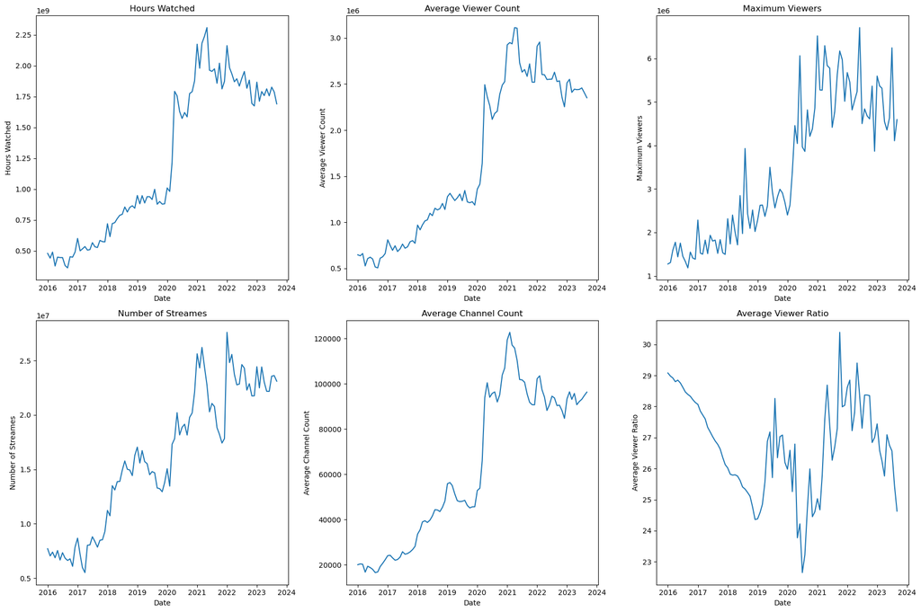

```python
df_twitch_global['Date'] = pd.to_datetime(df_twitch_global['Date'])

# Set up the matplotlib figure
plt.figure(figsize=(18, 12))

# Metrics to plot
metrics = ['Hours Watched', 'Average Viewer Count', 'Maximum Viewers', 'Number of Streames', 'Average Channel Count', 'Average Viewer Ratio']

# Creating a 2x3 grid of subplots
for i, metric in enumerate(metrics, 1):
    plt.subplot(2, 3, i)
    sns.lineplot(x='Date', y=metric, data=df_twitch_global)
    plt.title(f'{metric}')
    plt.xlabel('Date')
    plt.ylabel(metric)

plt.tight_layout()
plt.show()
```

How cool! Instead of having to write up code and printing out each individual plot in your notebook we can print out several subplots at the same time and see such different data and information all at once!

Note: Plotting your data is something that is so important because you will be able to physically SEE the trends rather than having to look at tables and figure out what the trend is just by numbers. After we gather this information, it can be used in so many ways such as maintaining or reviving growth of the platform, data could be applied to improve user engagement tactics, focused marketing campaigns, and perhaps even diversify content offerings.

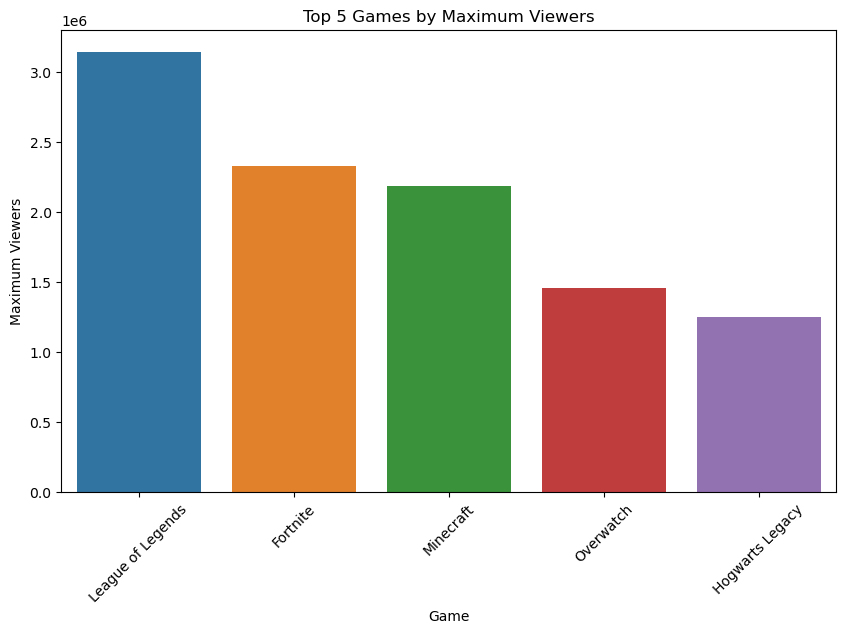

```python
# Let's plot the Top 5 games based on maximum viewers
top_games = twitch_total_df.groupby('Game').max().sort_values(by='Maximum Viewers', ascending=False).head(5).reset_index()

plt.figure(figsize=(10, 6))
sns.barplot(x='Game', y='Maximum Viewers', data=top_games)
plt.title('Top 5 Games by Maximum Viewers')
plt.xlabel('Game')
plt.ylabel('Maximum Viewers')
plt.xticks(rotation=45)
plt.show()
```

Wow! look at that, now we have a bar plot to show our data. By displaying the highest number of viewers each game has ever drawn at any given time, the plot draws attention to each game's peak popularity. This can be used to talk about which games have the biggest events that bring big crowds or which games are the most captivating. We can easily see in this plot that League of Legends is the most popular game to be watched on Twitch. This plot can be used to evaluate how well-suited various game genres or styles are for drawing sizable crowds. For example, contrasting sandbox games like Minecraft or battle royale games like Fortnite with eSports-focused games like League of Legends and Overwatch. Companies, can see which type of games people are most attracted to watch, which can be used as a marketing plan to increase their platform.

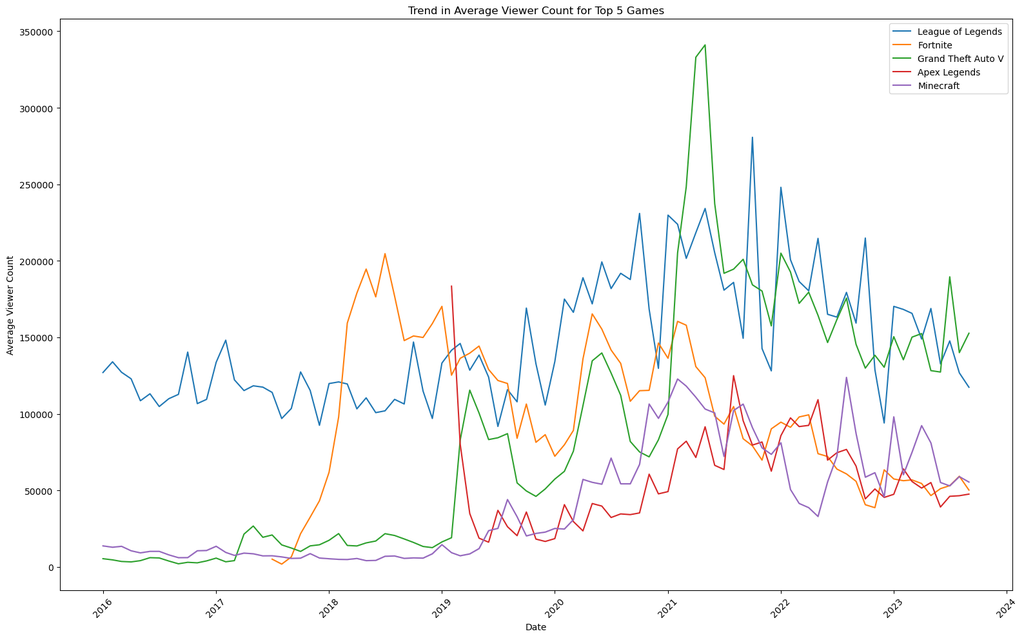

```python
twitch_total_df['Date'] = twitch_total_df['Date'].dt.to_timestamp()

# Here we identify the top 5 games based on the mean of their 'Average Viewer Count'
top_games = twitch_total_df.groupby('Game')['Average Viewer Count'].mean().nlargest(5).index
# Filtering the DataFrame to include only entries from these top 5 games
top_games_data = twitch_total_df[twitch_total_df['Game'].isin(top_games)]

plt.figure(figsize=(16, 10))
plt.title('Trend in Average Viewer Count for Top 5 Games')
plt.xlabel('Date')
plt.ylabel('Average Viewer Count')

# Here we are plotting each top games trend.
for game in top_games:
    game_data = top_games_data[top_games_data['Game'] == game]
    sns.lineplot(data=game_data, x='Date', y='Average Viewer Count', label=game)

plt.legend()
plt.xticks(rotation=45)
plt.tight_layout()
plt.show()
```

This plot above demonstrates the trends in average viewer count for the top five games on Twitch over several years. We can see in this plot that every one of these games hate their peak, showing us that there are different periods of high interest in different games.

It is honestly just so interesting that we have found out so much information just from a small amount of graphs. The power of data visualization!

# Model: Analysis, Hypothesis testing, and ML:

The next step of the data science process is model analysis and using these models to create hypothesis tests. In this step, we attempt to make various predictions of the databases and visualizations we have gathered using algorithms, [linear regression](https://www.w3schools.com/datascience/ds_linear_regression.asp), or any other hypothesis functions/tests.

For our specific case, we have predicted the average view for each game in our database for each month in a chosen 2 years (starting October 2023). Here we have used a [gradient descent algorithm](https://www.geeksforgeeks.org/gradient-descent-algorithm-and-its-variants/) to help model and predict certain parameters for a linear regression model.

We want to make it so that we can label each month after 2016 by an integer (1,2,3,...), so

Convert date to number of months (the independent variable) number of months = months after start of 2016

```python
df_tg_modified = pd.DataFrame(df_twitch_games)
df_tg_modified["months_after_2016"] = df_tg_modified["Date"].apply(lambda date_str: 12 * (date_str.year - 2016) + date_str.month)
```

Now, lets get all the games and set up a new dataframe specifically for modeling our gradient descent algorithm.

```python
all_games = df_twitch_games["Game"].unique()
predicted_data = pd.DataFrame(columns=["Game", "Month", "Average Viewer Count"])
```

Lets now define our parameters for our algorithm.

```python
# Define to predict each month for 2 years starting October 2023
PREDICTED_MONTHS = list(range(94, 118)) # <-- change this if you want to change what months to predict
PREDICTED_MONTHS_NP = np.array(PREDICTED_MONTHS).reshape(-1, 1)
# Other prediction criteria
AVG_VIEWS_MIN = 1000
SAMPLE_SIZE_MIN = 30
RAND_SEED = 20
# max_iter = 100 thousand - 1 million for faster but less accurate
# max_iter = 1 million - 5 million are more accurate, but will take significantly longer
# MAX_ITERS = 5000000
MAX_ITERS = 5000000
```

We have comments to change our parameter specficially for MAX_ITERS. This ranged depending on how accurate we want our prediction to be.

Now we want to count the number of games with certain criterias. We can see that we want the average count to be at least 1000 views, and the game we iterate through's data length to be over a certain amount.

After that, we want to iterate through all of our games meeting a certain criteria. We can use the [SGDRegression model](https://scikit-learn.org/stable/modules/generated/sklearn.linear_model.SGDRegressor.html) from scikit learn to model the behavior in which our criteria-met game average viewer count behaves.

```python
# Count number of games matching criteria (see conditions inside the for loop)
tmp_a = 0
for g in all_games:
    df_tgm_game_only = df_tg_modified[df_tg_modified["Game"] == g]
    if df_tgm_game_only.loc[:, "Average Viewer Count"].mean() >= AVG_VIEWS_MIN and len(df_tgm_game_only["months_after_2016"]) >= SAMPLE_SIZE_MIN:
        tmp_a += 1

print("Processing " + str(tmp_a) + " games... ", end="")

# Go through all games (with a condition mentioned below)
tmp_b = 0
for g in all_games:
    df_tgm_game_only = df_tg_modified[df_tg_modified["Game"] == g]

    # Only process games where average view count in the time period is >= AVG_VIEWS_MIN.
    # And only process games where n >= SAMPLE_SIZE_MIN for a better representative result.
    # (besides, the train_test_split cannot split samples where the sample size is too small)
    if df_tgm_game_only.loc[:, "Average Viewer Count"].mean() >= AVG_VIEWS_MIN and len(df_tgm_game_only["months_after_2016"]) >= SAMPLE_SIZE_MIN:
        # Setup variables
        y = df_tgm_game_only["Average Viewer Count"].to_numpy()
        x = df_tgm_game_only["months_after_2016"].to_numpy().reshape(-1, 1)

        x_train, x_test, y_train, y_test = ms.train_test_split(x, y, test_size=0.2, random_state=RAND_SEED)

        # Setup regressor
        sgdr = SGDRegressor(max_iter=MAX_ITERS, alpha=0.0001, tol=0.0001, learning_rate="constant", random_state=RAND_SEED, eta0=1e-7)
        sgdr.fit(x_train, y_train)
        pred_vals = sgdr.predict(PREDICTED_MONTHS_NP)

        # Add each of the rows to the table
        for i in range(0, len(pred_vals)):
            predicted_data.loc[predicted_data.index.max() + 1 if predicted_data.index.max() is not np.nan else 0] = [g, PREDICTED_MONTHS[i], pred_vals[i]]

        # Status print
        tmp_b += 1
        print(str(tmp_b) + " ", end="")
print("\nProcessing completed")

predicted_data
```

```
Processing 147 games... 1 2 3 4 5 6 7 8 9 10 11 12 13 14 15 16 17 18 19 20 21 22 23 24 25 26 27 28 29 30 31 32 33 34 35 36 37 38 39 40 41 42 43 44 45 46 47 48 49 50 51 52 53 54 55 56 57 58 59 60 61 62 63 64 65 66 67 68 69 70 71 72 73 74 75 76 77 78 79 80 81 82 83 84 85 86 87 88 89 90 91 92 93 94 95 …
Processing completed
```

|  | Game | Month | Average Viewer Count |
| --- | --- | --- | --- |
| 0 | League of Legends | 94 | 226766.304432 |
| 1 | League of Legends | 95 | 228613.249535 |
| 2 | League of Legends | 96 | 230460.194638 |
| 3 | League of Legends | 97 | 232307.139741 |
| 4 | League of Legends | 98 | 234154.084844 |
| ... | ... | ... | ... |
| 3523 | Project Zomboid | 113 | 6989.668107 |
| 3524 | Project Zomboid | 114 | 7051.516034 |
| 3525 | Project Zomboid | 115 | 7113.363962 |
| 3526 | Project Zomboid | 116 | 7175.211889 |
| 3527 | Project Zomboid | 117 | 7237.059817 |

3528 rows × 3 columns

Lets now graph our predictions to visually understand what we are looking at.

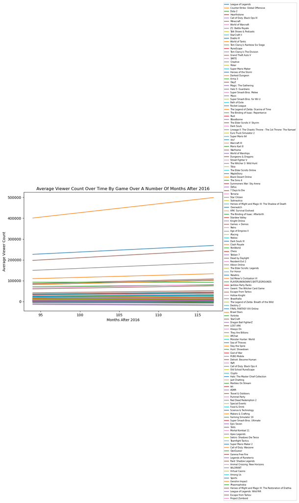

```python
plt.figure(figsize=(10, 6))

# Iterate through the games, grabbing their average view count.
for game in predicted_data['Game'].unique():
    game_data = predicted_data[predicted_data['Game'] == game]
    plt.plot(game_data['Month'], game_data['Average Viewer Count'], label=game)
plt.xlabel('Months After 2016')
plt.ylabel('Average Viewer Count')
plt.title('Average Viewer Count Over Time By Game Over A Number Of Months After 2016')
plt.legend(loc='center left', bbox_to_anchor=(1, 0.5), fontsize = 6)
plt.show()
```

We can see lots of games graphed here, of course only the highest predicted average viewer counts are most distinctable from the rest of the data. But now that we have the data, we can predict and plot lots of different aspects of upcoming games on Twitch.

# Interpretation: Insight & Policy Decision:

The last step and phase of the data science process and of this study is to simply interpret and conclude on our findings. Everything that has led up to here was thanks to being able to collect, clean, visualize, predict, and model data.

Inferring from our data, we can safely say that the game(s) that have a clear path to a huge average viewer count are as following:

#### 1) Counter-Strike Global Offensive

#### 2) League of Legends

#### 3) Minecraft

We as well have crucial data in predicting how many average views each game in our database will receive within a certain period in the future.

Hopefully by combining something interesting and relative towards the gaming community as well as data science, we gave you insight on what the **data science process** is like for something as simple as predicting average viewer counts.

To learn more, feel free to visit the following: 1) [Twitch Categories](https://www.twitch.tv/directory) 2) [Data Science Process](https://www.geeksforgeeks.org/data-science-process/)